# ModelTS

Romanova

4 апреля 2019 г

Модельные данные (COL4, COL10).

```r
ts.data<-read.table("stud2005.csv",header = TRUE,dec=",",sep = ";")
ts4<-ts(ts.data$COL4)
ts10<-ts(na.omit(ts.data$COL10))
```

Разберемся сначала с рядом COL4.

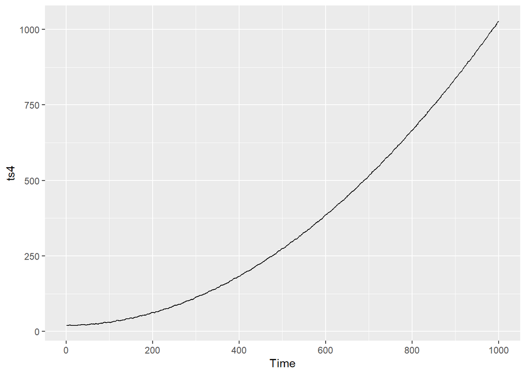

```r
autoplot(ts4)
```

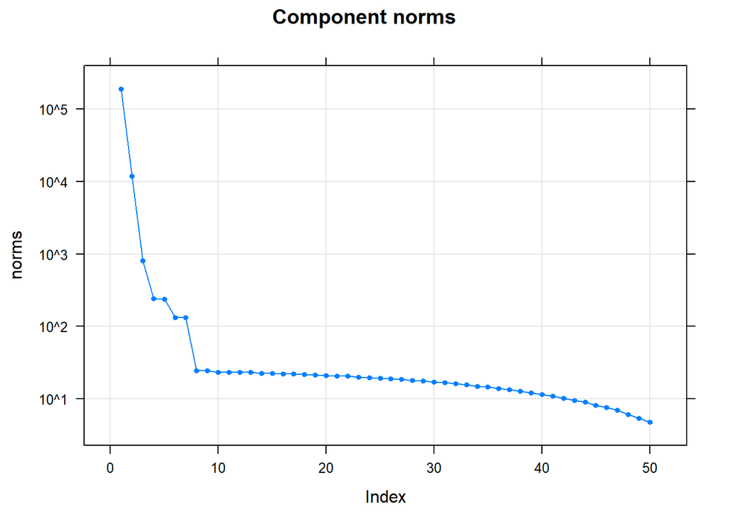

```r
ssa4<-ssa(ts4, L=500)
plot(ssa4)
```

Уже по этому графику норм компонент можно увидеть пары одинаковых собственных чисел (4-5 и 6-7), а также то, что, начиная с 8й компоненты, собственные числа мало отличаются. Возможно, стоит рассматривать как раз 7 первых компонент. Но мы на всякий случай рассмотрим побольше (11).

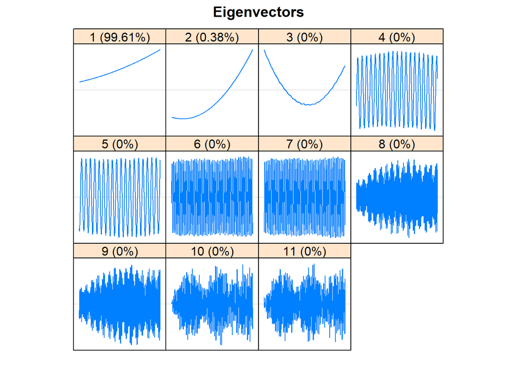

```r
plot(ssa4, type = "vectors", idx = 1:11)
```

Первый вектор однозначно соответствует тренду. 2-3 вроде тоже. Рассмотрим попарно остальные.

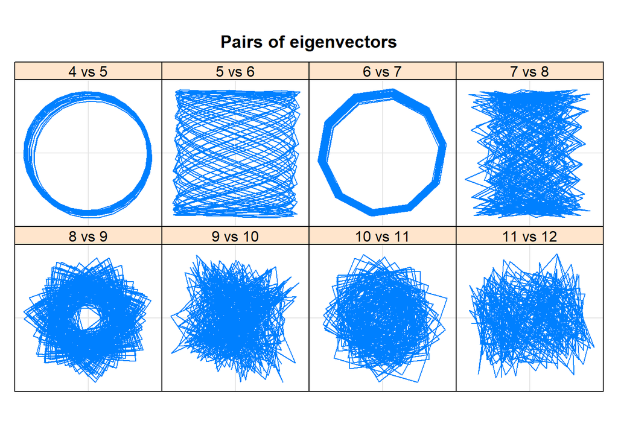

```r
plot(ssa4, type = "paired", idx = 4:11, plot.contrib = FALSE)
```

Видим, что вектор 4-5 и 6-7 образуют пары. 6-7 с периодом 10, а 4-5 не понятно, какой-то большой период, уточним:

```r
print(parestimate(ssa4, groups = list(4:5),
                  method = "pairs"))
```

```
##    period     rate   |    Mod     Arg  |     Re        Im
##    26.996   0.000000 |  1.00000   0.23 |  0.97304   0.23065
```

Период пары 4-5 равен 27.

Reconstructed series:

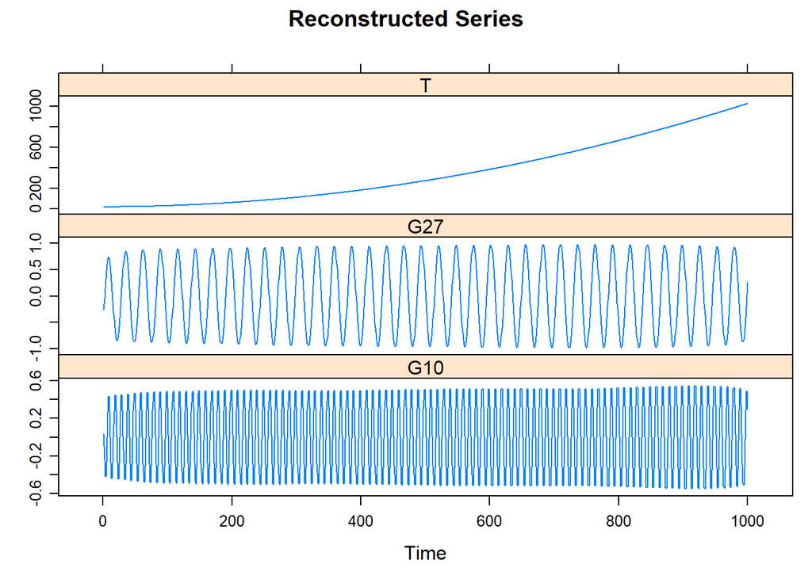

```r
plot(reconstruct(ssa4, groups = list(T=1:3,G27 = 4:5, G10 = 6:7)),
     plot.method = "xyplot", layout = c(1,3),
     add.residuals = FALSE, add.original = FALSE)
```

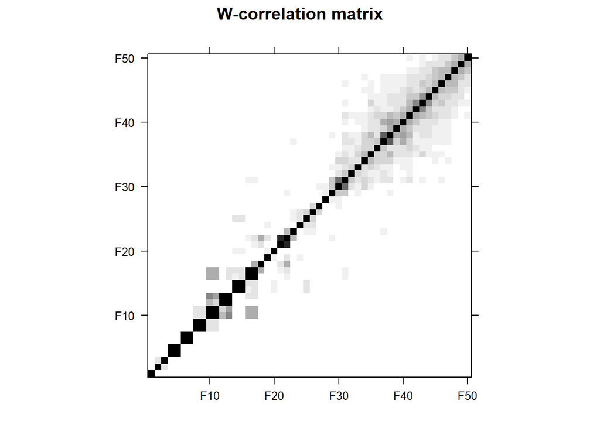

```r
plot(wcor(ssa4, groups = 1:50),
          scales = list(at = c(10, 20, 30,40,50)))
```

Первые три квадратика – тренд (не коррелируют с остальными…почти (2 и 3 коррелируют друг с другом немного)). Следующие два квадратика – 2 гармоники (синусы сильно коррелируют с соответствующими косинусами в паре и не коррелируют ни с чем остальным). Остальное – шум.

Положим первые 3 компоненты в тренд, 4:7 – в периодичность.

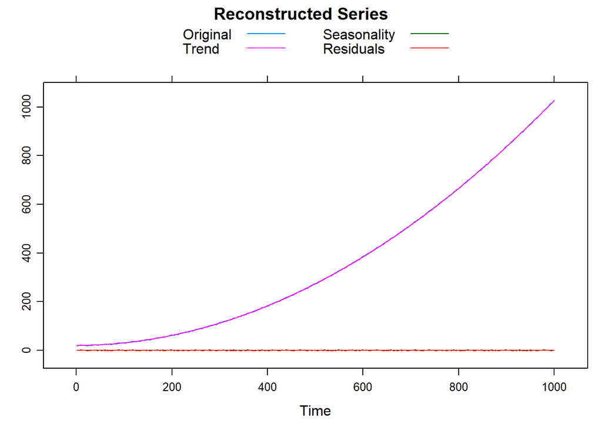

```r
reconstruct4<- reconstruct(ssa4,
                      groups = list(Trend = 1:3,
                                    Seasonality = 4:7))
plot(reconstruct4, add.residuals = TRUE, add.original = TRUE,
     plot.method = "xyplot",
     superpose = TRUE, auto.key = list(columns = 2))
```

Периодограмма остатков:

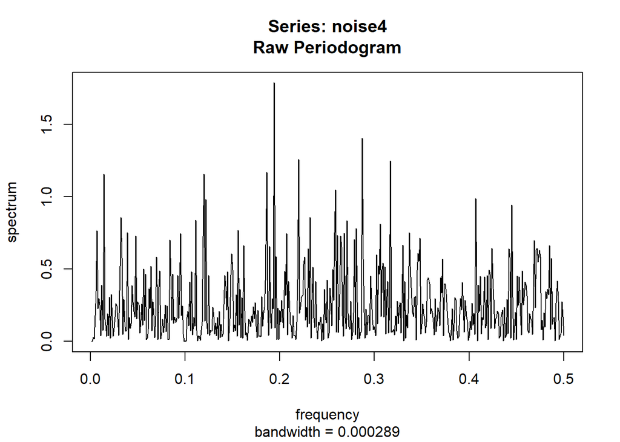

```r
noise4<-ts4-reconstruct4$Trend-reconstruct4$Seasonality
spec.pgram(noise4,log="no")
```

Вроде бы никакой сильной периодичности не осталось.

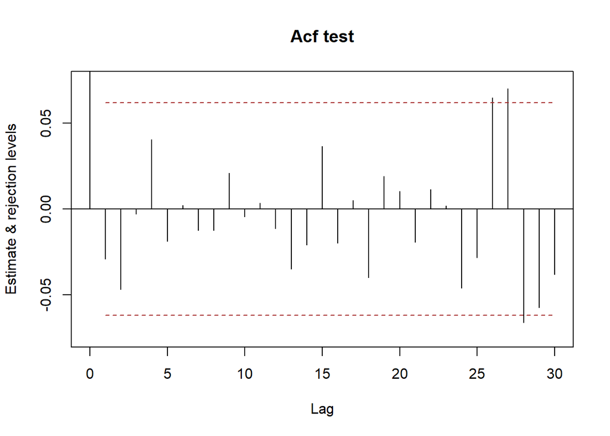

```r
autocor.noise<- autocorrelations(noise4, maxlag = 30)
plot(autocor.noise)
```

```r
whiteNoiseTest(autocor.noise, h0 = "iid",method = "LjungBox",interval=FALSE) #"LiMcLeod" (default), "LjungBox", "BoxPierce".
```

```
## $test
##          ChiSq DF    pvalue
## [1,] 0.8473242  1 0.3573104
## attr(,"method")
## [1] "LjungBox"
##
## $ci
##      int
## [1,]   0 0
## attr(,"level")
## [1] FALSE
```

Ну надо же. Гипотеза о том, что остался белый шум не отверглась. Ура! (всегда бы так…)

Разбираемся со вторым модельным рядом.

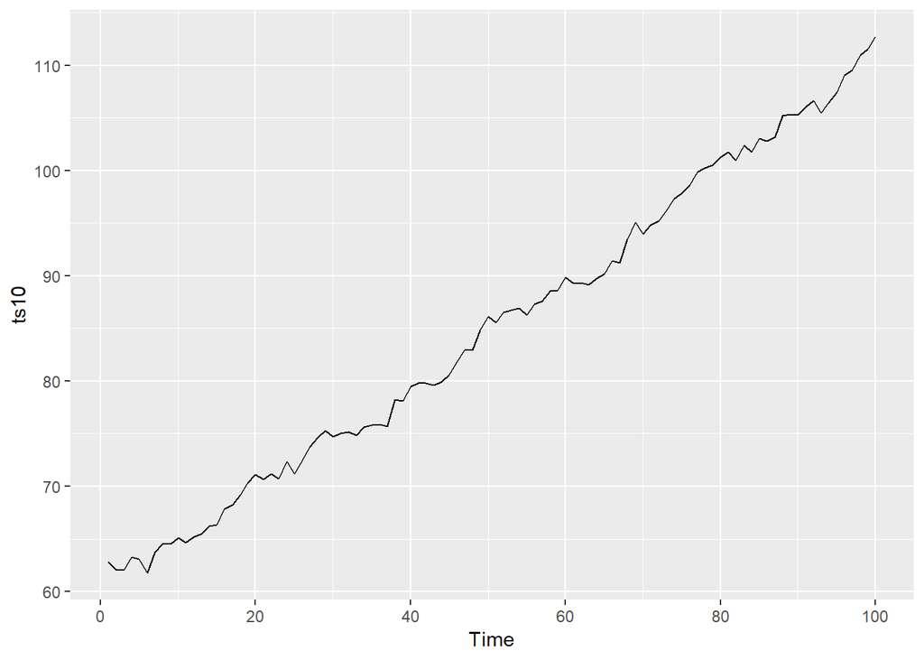

```r
autoplot(ts10)
```

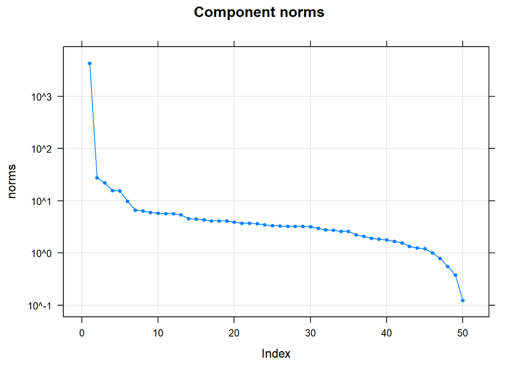

```r
ssa10<-ssa(ts10, L=50)
plot(ssa10)
```

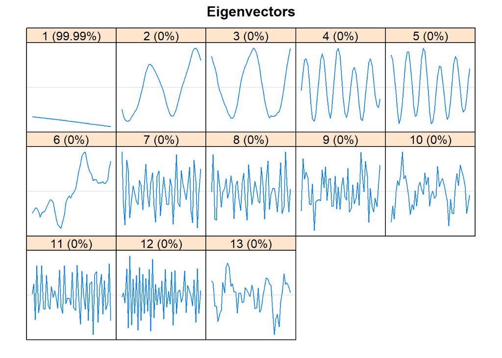

```r
plot(ssa10, type = "vectors", idx = 1:13)
```

Первая компонента – тренд. Рассмотрим попарно остальные.

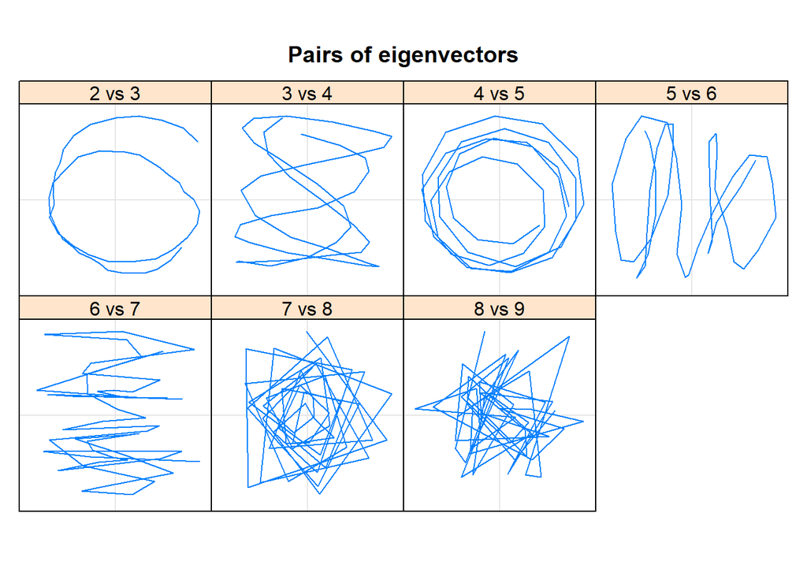

```r
plot(ssa10, type = "paired", idx = 2:8, plot.contrib = FALSE)
```

```r
print(parestimate(ssa10, groups = list(2:3,4:5),
                  method = "pairs"))
```

```
## $F1
##    period     rate   |    Mod     Arg  |     Re        Im
##    22.151   0.000000 |  1.00000   0.28 |  0.96004   0.27986
##
## $F2
##    period     rate   |    Mod     Arg  |     Re        Im
##    10.039   0.000000 |  1.00000   0.63 |  0.81045   0.58581
```

```r
print(parestimate(ssa10, groups = list(2:3,4:5), method = "esprit"))
```

```
## $F1
##    period     rate   |    Mod     Arg  |     Re        Im
##    28.276   0.004682 |  1.00469   0.22 |  0.97999   0.22142
##   -28.276   0.004682 |  1.00469  -0.22 |  0.97999  -0.22142
##
## $F2
##    period     rate   |    Mod     Arg  |     Re        Im
##    10.221  -0.009592 |  0.99045   0.61 |  0.80914   0.57121
##   -10.221  -0.009592 |  0.99045  -0.61 |  0.80914  -0.57121
```

pairs выдает разные периоды и большую ошибку. Больше доверяем esprit. Похоже (+- похоже), что пары 2:3 и 4:5 есть гармоника.

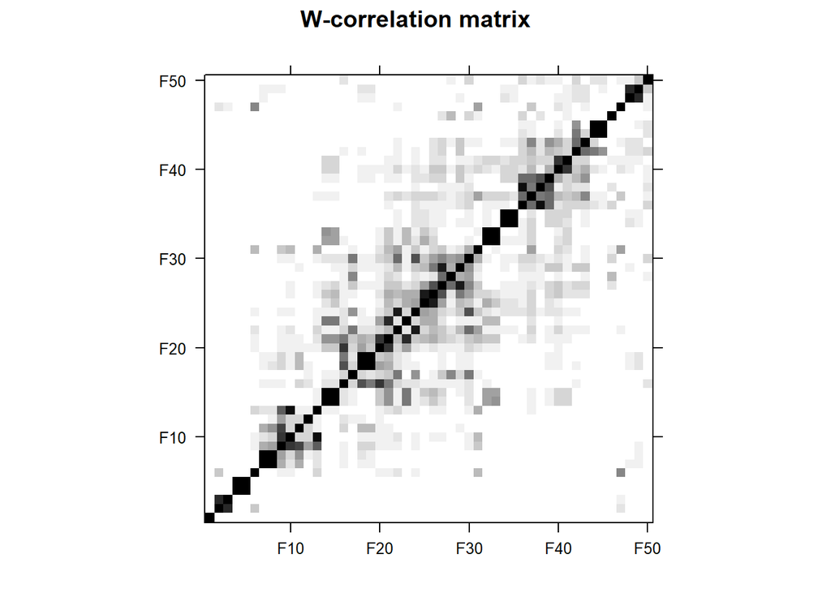

```r
plot(wcor(ssa10, groups = 1:50),
          scales = list(at = c(10, 20, 30,40,50)))
```

Тоже самое. 1 тренд, 2 гармоники. То, что одна из гармоник коррелирует с чем-то еще может значить, что между ней и каким-то шумом нет сильной разделимости. Тогда в этот кусок могла попасть часть шума. Но что делать…

Положим первую компоненту в тренд, 2:5 – в периодичность.

Reconstructed series:

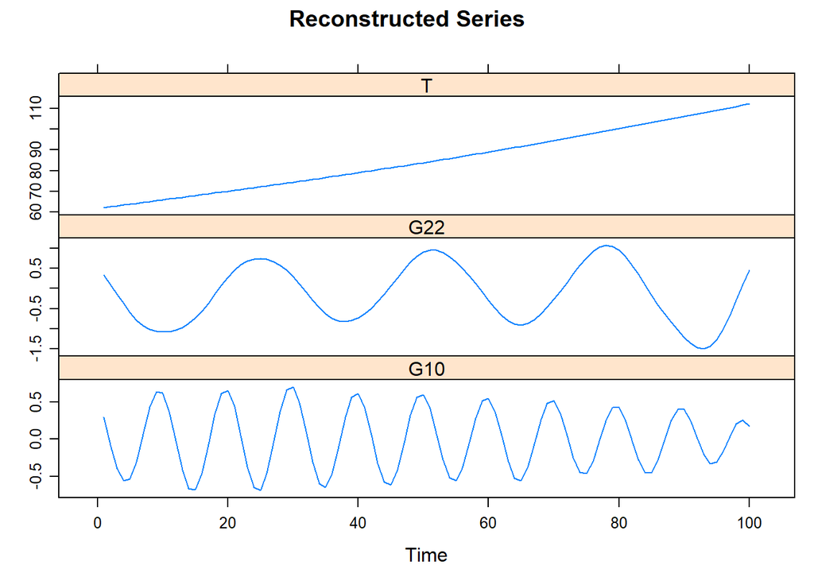

```r
plot(reconstruct(ssa10, groups = list(T=1,G22 = 2:3, G10 = 4:5)),
     plot.method = "xyplot", layout = c(1,3),
     add.residuals = FALSE, add.original = FALSE)
```

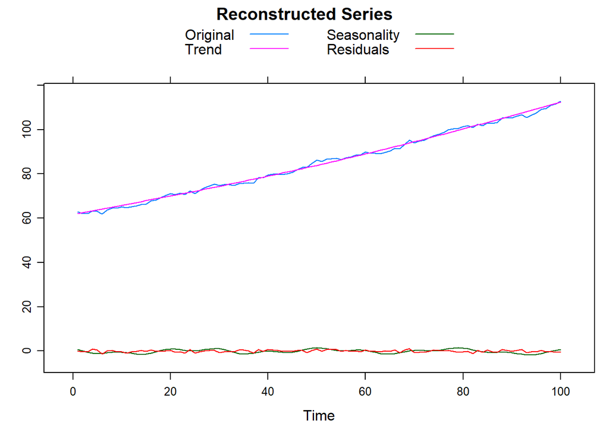

```r
reconstruct10<- reconstruct(ssa10,
                      groups = list(Trend = 1,
                                    Seasonality = 2:5))
plot(reconstruct10, add.residuals = TRUE, add.original = TRUE,
     plot.method = "xyplot",
     superpose = TRUE, auto.key = list(columns = 2))
```

Периодограмма остатков:

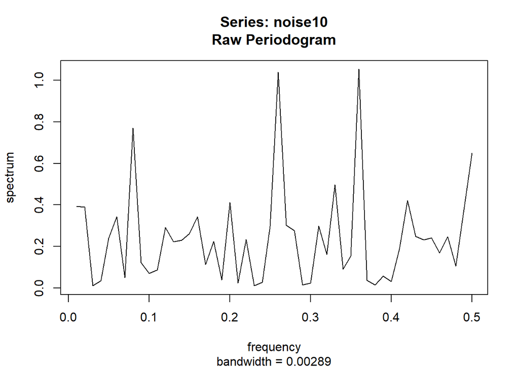

```r
noise10<-ts10-reconstruct10$Trend-reconstruct10$Seasonality
spec.pgram(noise10,log="no")
```

С одной стороны, вроде как похоже на оставшуюся периодичность (пики). Но наблюдений так мало, что это вполне могут быть просто случайные пики.

Проверка гипотезы о том, что остаток – белый шум.

```r
autocor.noise10<- autocorrelations(noise10, maxlag = 10)
whiteNoiseTest(autocor.noise10, h0 = "iid",method = "LjungBox",interval=FALSE) #"LiMcLeod" (default), "LjungBox", "BoxPierce".
```

```
## $test
##         ChiSq DF    pvalue
## [1,] 0.160193  1 0.6889789
## attr(,"method")
## [1] "LjungBox"
##
## $ci
##      int
## [1,]   0 0
## attr(,"level")
## [1] FALSE
```

P.S.: на самом деле если не брать вторую периодику (4:5), то гипотеза о том, что остаток – белый шум, тоже не отвергается. В случае длинного ряда вроде как вторую периодику отчетливо видно, но…гипотеза тоже не отвергается, если не брать вторую периодику. Надо проверить, что за критерий.